## EDGC ML study group

**Byungju Kim** Ph.D.  
Research Scientist / Bioinformatics Team  
# 291 Harmony-ro, Yeonsu-gu, Incheon  
mobile : +82-10-5091-8731  
email : byungju.kim@edgc.com

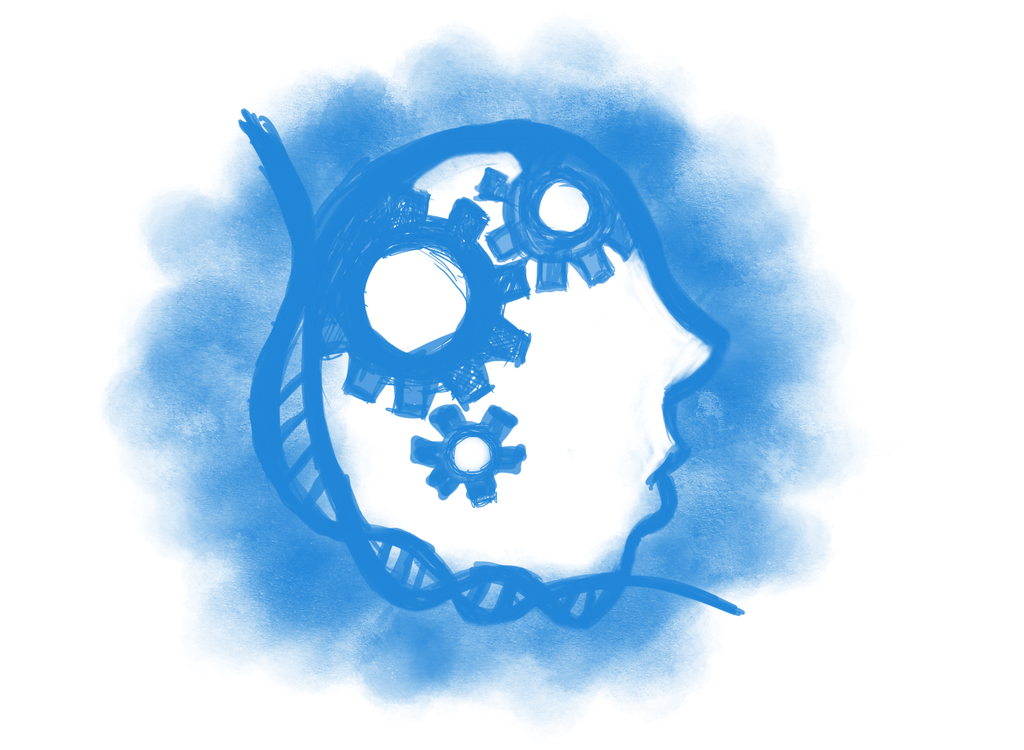

##### Chapter 1 : The Machine Learning Landscape Author : Byungju Kim Date : 2018-10-01

## What is the ML ?

**Machine Learning** is a Method for teaching computer (self-teaching) to make and improve predictions or behaviors based on the data.

- Some Quotes about Machine Learning

> “ Give a computer the ability to learn without being explicitly programmed.  
> — **Athur Samuel (1901-1990)**

well proposed learning problem :

> “A computer program is said to learn from experience **E** with respect to some task **T** and some performance measure **P**, if its performance on **T**, as measured by **P**, improves with experience **E**.  
> — **Tom Mitchell (1951-present)**

## Some basic terms

**Data** - our information for analysis.

- Quantitative, continuous data.
- Qualitative, categorical data.

Generally, Data is matrix/Data frame.

$$X = \left( \begin{array} {rrrr}
x_{11} & x_{12} & \cdots & x_{1p} \\
x_{21} & x_{22} & \cdots & x_{2p} \\
\vdots & \vdots & \ddots & \vdots \\
x_{n1} & \cdots & \cdots & x_{np} \\
\end{array} \right)$$

- n : number of observation.
- p : number of variables that are available for use in making predictions.
- $x_{i,j}$ is element of an X matrix, representing the value of the jth variable for the ith observation, where i = 1, 2,…,n and j = 1, 2,…,p.

**Training** is the way of teaching the computer the data.

**Training set** is the data set used for training process.

**Testing/Validation** is the checking or proving the validity. (accuracy, error etc.)

**Testing set** is the subset of data which is used for the testing.

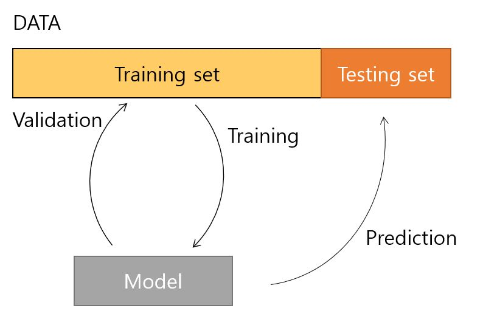

## Example :: Spam-Filter - binary classification.

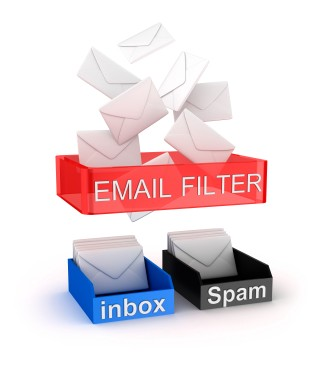

**DATA** : thousands of emails

**descriptor/predictor** : image to text ratio, some spam like words (e.g. free, credit card, etc …)

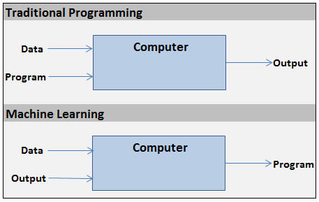

Benefits for choosing ML.

## Type of Machine learning

### supervised Learning : `Label O`

- *k*-Nearleast Neighbor (*k*-NN)
- support vector machine
- Decision Tree/Random Forest
- linear regression
- Logistic regression
- Naive bayes
- Neural Network

### Unsupervised Learning : `label X`

**clustering**

- k-Mean
- Hierarchical Clustering
- Expectation Maximization

**Visualization and Dimensional reduction**

- PCA
- PCA<sup>kernel</sup>
- Locally-linear Embedding (LLE)
- t-SNE

**Association rule learning**

- Apriori
- Eclat

### Semi-supervised learning : `label O + label X`

- Deep belief network
- restricted Boltzmann machine
- Reinforcement Learning

## Examples

### iris DATA

```r
str(iris)
```

```
## 'data.frame':    150 obs. of  5 variables:
##  $ Sepal.Length: num  5.1 4.9 4.7 4.6 5 5.4 4.6 5 4.4 4.9 ...
##  $ Sepal.Width : num  3.5 3 3.2 3.1 3.6 3.9 3.4 3.4 2.9 3.1 ...
##  $ Petal.Length: num  1.4 1.4 1.3 1.5 1.4 1.7 1.4 1.5 1.4 1.5 ...
##  $ Petal.Width : num  0.2 0.2 0.2 0.2 0.2 0.4 0.3 0.2 0.2 0.1 ...
##  $ Species     : Factor w/ 3 levels "setosa","versicolor",..: 1 1 1 1 1 1 1 1 1 1 ...
```

### GaltonFamily

```r
str(GaltonFamilies)
```

```
## 'data.frame':    934 obs. of  8 variables:
##  $ family         : Factor w/ 205 levels "001","002","003",..: 1 1 1 1 2 2 2 2 3 3 ...
##  $ father         : num  78.5 78.5 78.5 78.5 75.5 75.5 75.5 75.5 75 75 ...
##  $ mother         : num  67 67 67 67 66.5 66.5 66.5 66.5 64 64 ...
##  $ midparentHeight: num  75.4 75.4 75.4 75.4 73.7 ...
##  $ children       : int  4 4 4 4 4 4 4 4 2 2 ...
##  $ childNum       : int  1 2 3 4 1 2 3 4 1 2 ...
##  $ gender         : Factor w/ 2 levels "female","male": 2 1 1 1 2 2 1 1 2 1 ...
##  $ childHeight    : num  73.2 69.2 69 69 73.5 72.5 65.5 65.5 71 68 ...
```

### *k*-Nearleast Neighbor (*k*-NN)

- Most simplest alogrithm which find k samples ~~ majority of vote.

$$Dist_{(p,q)} = \sqrt{\sum_{x=1}^{n}{(p_{x}-q_{x})^2}}$$

- *n* dimensions

$$Dist_{(p,q)} = \sqrt{\sum_{x=1}^{n}{(p_{1}-q_{1})^2 + (p_{2}-q_{2})^2 + (p_{3}-q_{3})^2 ... (p_{n}-q_{n})^2}}$$

```r
   iris_dist<-dist(iris[,1:3],upper=T,diag=T)     ## calculate euclidean distance
   iris_dist<-as.data.frame(as.matrix(iris_dist)) ## change dist object -> matrix -> data.frame

   iris_dist[1:5,1:5]
```

```
##           1         2        3         4         5
## 1 0.0000000 0.5385165 0.509902 0.6480741 0.1414214
## 2 0.5385165 0.0000000 0.300000 0.3316625 0.6082763
## 3 0.5099020 0.3000000 0.000000 0.2449490 0.5099020
## 4 0.6480741 0.3316625 0.244949 0.0000000 0.6480741
## 5 0.1414214 0.6082763 0.509902 0.6480741 0.0000000
```

```r
   mds_iris<-cmdscale(iris_dist,eig=T,k=2)

   iris_mds_df<-as.data.frame(mds_iris$`points`)
   iris_mds_df$species<-iris$Species
   head(iris_mds_df)
```

```
##          V1         V2 species
## 1 -2.490880  0.3209734  setosa
## 2 -2.523343 -0.1784006  setosa
## 3 -2.711149 -0.1378201  setosa
## 4 -2.557756 -0.3156752  setosa
## 5 -2.538964  0.3313569  setosa
## 6 -2.135420  0.7505233  setosa
```

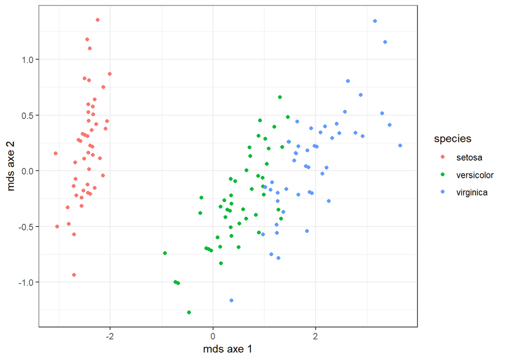

```r
   ggplot(iris_mds_df,aes(V1,V2,colour=species))+geom_point() + theme_bw() + xlab("mds axe 1") + ylab("mds axe 2")
```

[output not shown]